# Lab 2: Text Analysis of Nexis Uni Data

Data Center News Coverage

2026-04-19

## Overview

In this lab you will work with a corpus of news articles about data centers. They were written in the first 6 months of either 2021 or 2025 and retrieved from Nexis Uni and processed with the `LexisNexisTools` package. You will practice:

- Loading and inspecting a structured news corpus
- Tokenization, stemming, and lemmatization
- Building and applying domain-specific stopword lists
- Frequency analysis and visualization
- Keyness analysis to compare sub-corpora

**Packages used:**

```r
library(tidyverse)      # data wrangling and plotting
library(tidytext)       # text mining in tidy format
#library(LexisNexisTools) # reading Nexis Uni.docx exports
library(SnowballC)      # Porter stemmer
library(textstem)       # lemmatization
library(scales)         # axis formatting
library(lubridate)      # date handling
library(quanteda)       # corpus and DFM construction
library(quanteda.textstats) # textstat_keyness()
library(quanteda.textplots) # textplot_keyness()
```

## 1. Load and Inspect the Corpus

Today’s example uses data from Nexis Uni (formerly LexisNexis), a news and full-text publications database accessible through the UCSB library. We’ll examine media coverage of data center construction.

I used the `{LexisNexisTools}` package to parse `.docx` exports from Nexis. It returns an “S4” object with three slots accessed via `@`:

- `@meta` — article-level metadata (date, headline, newspaper)
- `@articles` — full article text
- `@paragraphs` — paragraph-level text

```r
# How you USE the NEXIS tool:

# pre_files <- list.files(
#   path = here::here("Nexis", "data-center"),
#   pattern = "\\.docx$",
#   full.names = TRUE,
#   recursive = TRUE,
#   ignore.case = TRUE
# )
#
# pre_dat <- lnt_read(pre_files) # Data object
#
# #  --- Reference the tables  / sub data info ---
# pre_meta_df       <- pre_dat@meta
# pre_articles_df   <- pre_dat@articles
# pre_paragraphs_df <- pre_dat@paragraphs
#
# # --- Construct a dataframe object from data sources ---
# df <- tibble(
#   date     = pre_meta_df$Date,
#   headline = pre_meta_df$Headline,
#   id       = pre_meta_df$ID,
#   text     = pre_articles_df$Article,
#   source   = pre_meta_df$Newspaper
# )


url <- "https://raw.githubusercontent.com/MaRo406/EDS-231-text-sentiment/refs/heads/main/data/nexis-dat.csv"
df <- read_csv(url)
```

### 1.1 Cleaning the raw text

Before any analysis, the raw Nexis export needs cleaning. Each step below addresses a specific artifact of how Nexis packages its data:

```r
# Drop articles with no date — these are often metadata rows, not real articles
df <- df[!is.na(df$date),]

# Remove URLs — Nexis embeds source URLs inline in the text body
df$text <- gsub("https?\\S+", "", df$text)

# Convert to ASCII — Nexis exports sometimes include curly quotes, em-dashes,
# and other Unicode characters that cause issues in tokenization
df$text <- iconv(df$text, to = "ASCII//TRANSLIT", sub = "") # remove artifacts of other methiod

# Also, remove possessives
df$text <- gsub("'s\\b", "", df$text) # removes when boundary of a word ends with 's
```

**Always good to do a quick inspection:**

```r
glimpse(df)
```

```
## Rows: 558
## Columns: 6
## $ ...1     <dbl> 1, 2, 3, 4, 5, 6, 7, 8, 9, 10, 11, 12, 13, 14, 15, 16, 17, 18…
## $ date     <date> 2025-05-01, 2021-05-23, 2021-03-09, 2025-06-26, 2025-02-20, …
## $ headline <chr> "\"Between the Storms\" chronicles a biologist's adventures o…
## $ id       <dbl> 1, 2, 3, 4, 5, 6, 7, 8, 9, 10, 11, 12, 13, 14, 15, 16, 17, 18…
## $ text     <chr> "Biologist, cartographer and builder Barry Devine has publish…
## $ source   <chr> "The Virgin Islands Daily News, St. Thomas", "CE Noticias Fin…
```

```r
# Summary data
cat("\nDate range:", format(min(df$date)), "to", format(max(df$date)), "\n")
```

```
##
## Date range: 2021-01-01 to 2025-06-30
```

```r
cat("Unique sources:", n_distinct(df$source), "\n")
```

```
## Unique sources: 136
```

```r
cat("Total articles:", nrow(df), "\n")
```

```
## Total articles: 558
```

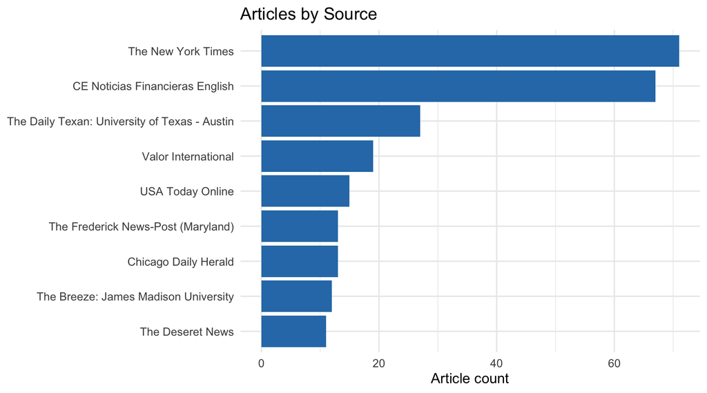

```r
df |>
  count(source, sort = TRUE) |> #
  filter(n > 10,
         source != "") |> #
  ggplot(aes(x = reorder(source, n), y = n)) +
  geom_col(fill = "#2c7bb6") +
  coord_flip() +
  labs(title = "Articles by Source",
       x = NULL, y = "Article count") +
  theme_minimal(base_size = 13)
```

## 2. Tokenization

The core `tidytext` workflow converts documents into a **one-token-per-row** format using `unnest_tokens()`. This makes every subsequent step a standard `dplyr` pipeline. We’ll select our columns of interest in df, then unnest the tokens (at the word level).

```r
# Every word is a row
tokens <- df |>
  select(id, date, source, text) %>%
  unnest_tokens(
    output = word, # new column name
    input = text, # input text col
    token = "words" # by words (sentences, ngrams)
  )


glimpse(tokens)
```

```
## Rows: 634,605
## Columns: 4
## $ id     <dbl> 1, 1, 1, 1, 1, 1, 1, 1, 1, 1, 1, 1, 1, 1, 1, 1, 1, 1, 1, 1, 1, …
## $ date   <date> 2025-05-01, 2025-05-01, 2025-05-01, 2025-05-01, 2025-05-01, 20…
## $ source <chr> "The Virgin Islands Daily News, St. Thomas", "The Virgin Island…
## $ word   <chr> "biologist", "cartographer", "and", "builder", "barry", "devine…
```

```r
cat("\nTotal tokens:", nrow(tokens) , "\n") # Number of words
```

```
##
## Total tokens: 634605
```

```r
cat("Unique tokens:", n_distinct(tokens) , "\n") # Number of unique words
```

```
## Unique tokens: 254539
```

**Discussion:** What does `unnest_tokens()` do to case and punctuation by default? Each row has the word from the original text - without capitizations!

## 3. Stopword Removal

### 3.1 Standard Stopwords

Recall that `tidytext` ships with several stopword lexicons via `get_stopwords()`. The most comprehensive built-in option is the SMART list, which covers around 570 high-frequency function words and is well-suited for news and document analysis. Let’s load the SMART words and remove them from our tokens.

```r
# Get the stop words
standard_sw <- get_stopwords(source = "smart")

tokens_clean <- tokens %>% anti_join(standard_sw, by = "word")

cat("Tokens after standard stopword removal:", nrow(tokens_clean), "\n")
```

```
## Tokens after standard stopword removal: 325237
```

### 3.2 **Domain-Specific Stopwords**

Standard lists were built for general text. News about data centers will include high-frequency words that are uninformative for *your* research questions — boilerplate legal language, news wire attributions, and domain-generic terms.

> **Methodological note:** Your stopword choices are *analytical decisions*, not neutral preprocessing. Document them and be prepared to justify them. A word that is uninformative for one research question may be the key signal for another.

**Step 1: Look at what’s still most frequent after standard stopword removal.**

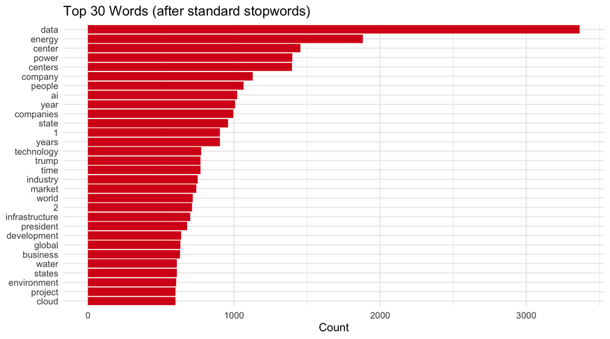

```r
tokens_clean |>
  count(word, sort = TRUE) |>
  slice_head(n = 30) |>
  ggplot(aes(x = reorder(word, n), y = n)) +
  geom_col(fill = "#d7191c") +
  coord_flip() +
  labs(title = "Top 30 Words (after standard stopwords)",
       x = NULL, y = "Count") +
  theme_minimal(base_size = 12)
```

**Step 2: Build a domain stopword list from what we observe.**

Look at the plot above. Add words that are frequent but analytically uninformative for your research question. Can you identify anything that we should remove?

```r
# New tibble with words assocated with article set up
domain_sw <- tibble(word = c(
 # News wire / attribution boilerplate
  "said", "says", "told", "according", "reported", "noted", "added",
  "stated", "announced", "mr", "ms", "inc", "corp", "llc",
  # Generic quantitative terms ##(adjust based on your research question)
  "year", "years", "percent", "million", "billion", "quarter",
  "company", "companies", "firm", "business",
  # Consider whether these are substantive for our RQ:
  "data", "center", "centers"
))


tokens_clean2 <- tokens_clean |>
  anti_join(domain_sw, by = "word") |>
  filter(
    !str_detect(word, "^[0-9]+$"),    #remove pure digit tokens... No pure numbers
    str_length(word) > 2            #remove very short tokens
  )

cat("Tokens after domain stopword removal:", nrow(tokens_clean2), "\n")
```

```
## Tokens after domain stopword removal: 296257
```

```r
cat("Reduction from raw:", scales::percent(1 - nrow(tokens_clean2) / nrow(tokens)), "\n")
```

```
## Reduction from raw: 53%
```

## 4. Stemming and Lemmatization

Both stemming and lemmatization reduce words to a base form to consolidate variant spellings. They differ in approach and output. We’ll just run the code in 4. as a demonstration of these tools.

### 4.1 Stemming (Porter Stemmer)

```r
tokens_stemmed <- tokens_clean2 |>
  mutate(stem = wordStem(word, language = "english"))

# Compare original tokens to their stems
tokens_stemmed |>
  filter(word != stem) |>
  distinct(word, stem) |>
  slice_head(n = 20) |>
  knitr::kable(caption = "Sample: original tokens vs. stems")
```

Sample: original tokens vs. stems

| word | stem |
| --- | --- |
| cartographer | cartograph |
| barry | barri |
| devine | devin |
| published | publish |
| storms | storm |
| chronicling | chronicl |
| adventures | adventur |
| story | stori |
| finding | find |
| loving | love |
| leaving | leav |
| paradise | paradis |
| early | earli |
| realized | realiz |
| questions | question |
| parents | parent |
| lives | live |
| unanswered | unansw |
| dreams | dream |
| successes | success |

Look at the stem column. Do any stems look wrong or ambiguous?

### 4.2 Lemmatization

```r
tokens_lemmatized <- tokens_clean2 |>
  mutate(lemma = lemmatize_words(word))

# Compare
tokens_lemmatized |>
  filter(word != lemma) |>
  distinct(word, lemma) |>
  slice_head(n = 20) |>
  knitr::kable(caption = "Sample: original tokens vs. lemmas")
```

Sample: original tokens vs. lemmas

| word | lemma |
| --- | --- |
| published | publish |
| storms | storm |
| chronicling | chronicle |
| adventures | adventure |
| finding | find |
| loving | love |
| leaving | leave |
| older | old |
| realized | realize |
| questions | question |
| parents | parent |
| lives | life |
| left | leave |
| dreams | dream |
| successes | success |
| inspired | inspire |
| answers | answer |
| thought | think |
| born | bear |
| queens | queen |

**Compare the two approaches on a specific word family:**

```r
comparison_words <- c("operating", "operated", "operations", "operator", "operators",
                      "building", "built", "builds", "build")

tokens_clean2 |>
  filter(word %in% comparison_words) |>
  mutate(
    stem  = wordStem(word),
    lemma = lemmatize_words(word)
  ) |>
  distinct(word, stem, lemma) |>
  arrange(word) |>
  knitr::kable(caption = "Stemming vs. lemmatization comparison")
```

Stemming vs. lemmatization comparison

| word | stem | lemma |
| --- | --- | --- |
| build | build | build |
| building | build | build |
| builds | build | build |
| built | built | build |
| operated | oper | operate |
| operating | oper | operate |
| operations | oper | operation |
| operator | oper | operator |
| operators | oper | operator |

**Discussion:** Which approach would you choose for this corpus, and why?

For the rest of this lab we will use **lemmatized** tokens.

```r
working_tokens <- tokens_lemmatized |>
  mutate(word = lemma) |>
  select(-lemma)
```

## 5. Frequency Analysis

### 5.1 Overall Frequency

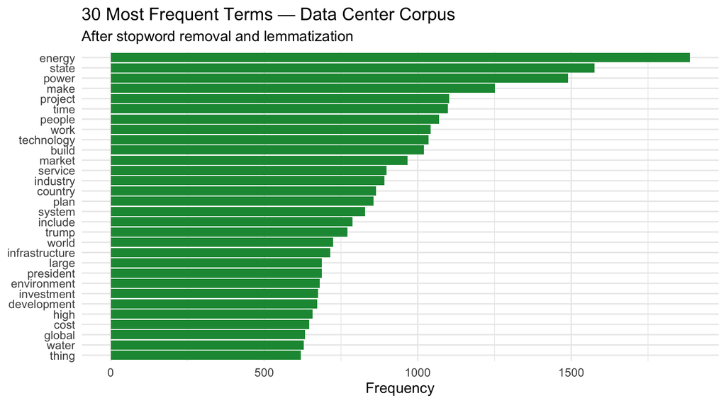

```r
top_words <- working_tokens |>
  count(word, sort = TRUE) |>
  slice_head(n = 30)

top_words |>
  ggplot(aes(x = reorder(word, n), y = n)) +
  geom_col(fill = "#1a9641") +
  coord_flip() +
  labs(
    title = "30 Most Frequent Terms — Data Center Corpus",
    subtitle = "After stopword removal and lemmatization",
    x = NULL,
    y = "Frequency"
  ) +
  theme_minimal(base_size = 13)
```

### 5.2 Frequency by Source

Raw frequency across the whole corpus can mask differences between outlets. This plot shows each source’s top 10 terms independently — useful for spotting whether specific publications drive particular terms in the overall frequency list.

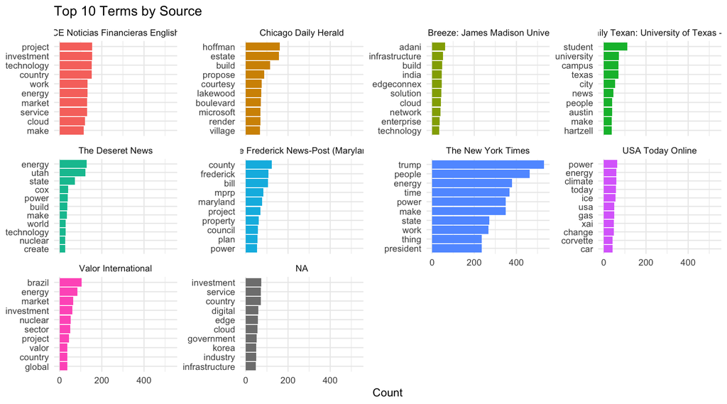

```r
top_sources <- df |>
  count(source, sort = TRUE) |>
  slice_max(n, n = 10) |> #select rows with largest values
  pull(source) #extract source column only

working_tokens |>
  filter(source %in% top_sources) |>
  count(source, word, sort = TRUE) |> #ungroup,transform,group allows calculations but maintain row structure
  group_by(source) |>
  slice_max(n, n = 10) |>
  ungroup() |>
  ggplot(aes(x = reorder_within(word, n, source), y = n, fill = source)) +
  geom_col(show.legend = FALSE) +
  facet_wrap(~source, scales = "free_y") +
  scale_x_reordered() +
  coord_flip() +
  labs(title = "Top 10 Terms by Source", x = NULL, y = "Count") +
  theme_minimal(base_size = 10)
```

## 6. Keyness Analysis

Frequency tells us which words are common. Keyness tells us which words are *characteristic* — more common in one sub-corpus than you would expect given their overall rate. A word can be infrequent overall but highly distinctive of a particular group.

We use `quanteda` for this because `tidytext` doesn’t implement keyness statistics natively. `quanteda` represents text as a **document-feature matrix (DFM)** — the wide-format equivalent of the long tidy token table we’ve been using.

### 6.1 Build a corpus and DFM

```r
# Build corpus — quanteda uses character doc IDs, so id (integer) is coerced
corp <- corpus(df, docid_field = "id", text_field = "text") #Where our tidy tokens had one row per token, a DFM has one row per document and one column per unique token, with cell values being token counts.
docvars(corp, "year") <- format(df$date, "%Y")

# Tokenize inside quanteda: remove punctuation, numbers, symbols; lowercase
toks <- tokens(corp,
               remove_punct   = TRUE,
               remove_numbers = TRUE,
               remove_symbols = TRUE) |>
  tokens_tolower() |>
  tokens_remove(stopwords("en", source = "smart") ) #

# Build DFM and drop any documents with no date
dfmat <- dfm(toks)
dfmat <- dfmat[!is.na(docvars(dfmat, "year")), ]

cat("DFM dimensions:", nrow(dfmat), "documents ×", ncol(dfmat), "features\n")
```

```
## DFM dimensions: 558 documents × 25603 features
```

### 6.2 Define target and reference sub-corpora

We compare 2021 coverage against 2025 coverage. This span captures the period just before and after large-scale AI infrastructure investment became a dominant news frame — the launch of ChatGPT (late 2022) and subsequent hyperscaler announcements sit in between. You could equally split by source, geographic region, or any other variable in `docvars`.

```r
cat("2021 articles:", sum(docvars(dfmat, "year") == "2021"), "\n")
```

```
## 2021 articles: 246
```

```r
cat("2025 articles:", sum(docvars(dfmat, "year") == "2025"), "\n")
```

```
## 2025 articles: 312
```

```r
# Collapse DFM to two rows — one per year value
dfmat_grouped <- dfm_group(dfmat, groups = year)
```

### 6.3 Compute and plot keyness

`textstat_keyness()` defaults to `measure = "chi2"`. We use `measure = "lr"` (log-likelihood ratio, G²) because it handles sparse counts better than χ².

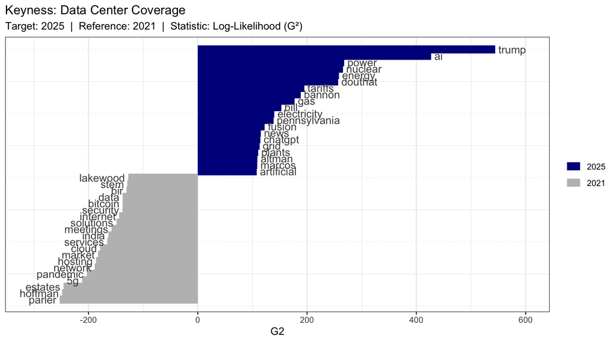

```r
result <- textstat_keyness(dfmat_grouped,
                           target  = "2025",
                           measure = "lr")

textplot_keyness(result, n = 20) +
  labs(
    title = "Keyness: Data Center Coverage",
    subtitle = "Target: 2025  |  Reference: 2021  |  Statistic: Log-Likelihood (G²)"
  )
```